# Basic statistics in R

**There is a presentation which goes with this handout, use it to add notes if you need to.**

Before we start, remember we need to do a couple of things…

#### 1. Tell R where your data are

See the introduction handout if you can’t remember how.

Check it worked using:

```r
list.files()
```

```
## [1] "04_basic-stats.Rmd"    "daphnia.growth.csv"    "garden.ozone.csv"
## [4] "growth.csv"            "ladybirds.csv"         "limpet.csv"
## [7] "plant.growth.rate.csv" "README.md"
```

or look at the Files tab

#### 2. Load the packages needed

We already downloaded these and don’t need to do that again. You may need to install `ggfortify` if you didn’t do that already.

```r
library(tidyverse)
library(ggfortify)
```

#### 3. Import the data

First we are going to work with the dataset `plant.growth.rate.csv`

```r
growth <- read_csv("plant.growth.rate.csv")
```

#### 4. Look at the data

```r
glimpse(growth)
```

```
## Observations: 50
## Variables: 2
## $ soil.moisture.content <dbl> 0.4696876, 0.5413106, 1.6979915, 0.82557...
## $ plant.growth.rate     <dbl> 21.31695, 27.03072, 38.98937, 30.19529, ...
```

### Which statistics do I need?

Before you start think very carefully about what your *question* is, why it is interesting, and how you’d plot it on a graph. If you can plot something, you can usually do the statistics!

As a (very) vague rule of thumb:

1. If you have a continuous response (Y) variable, and a categorical predictor/explanatory (X) variable you’ll need a t-test (two groups), or analysis of variance (ANOVA; two or more groups). You’d plot this as a boxplot (or barplot if you really want to - barplots suck).
2. If you have a continuous response (Y) variable, and a continuous predictor/explanatory (X) variable you’ll need a regression (one X), or multiple regression (two or more Xs). You’d plot this as a scatter plot.
3. If you have a continuous response (Y) variable, and a continuous predictor/explanatory (X) variable AND a categorical explanatory variable you’ll need an analysis of covariance (ANCOVA). You’d plot this as a scatter plot with two or more lines (one for each category of X).

There are **many** other options though, this is not exhaustive and isn’t always the best statistic to use for a given problem/dataset. Also note that we are only covering very basic statistics here. Many problems need something more complex.

### How do we do statistics - step by step

1. PLOT your data
2. Fit your model
3. Look at the assumptions
4. Look at the results
5. Add interpretation to your graph

### General linear models - regression

First we’ll use the plant growth dataset to demonstrate a linear regression…

#### 1. Plot the data

Make a scatter plot of `soil.moisture.content` on the x axis and `plant.growth.rate` on the y axis.

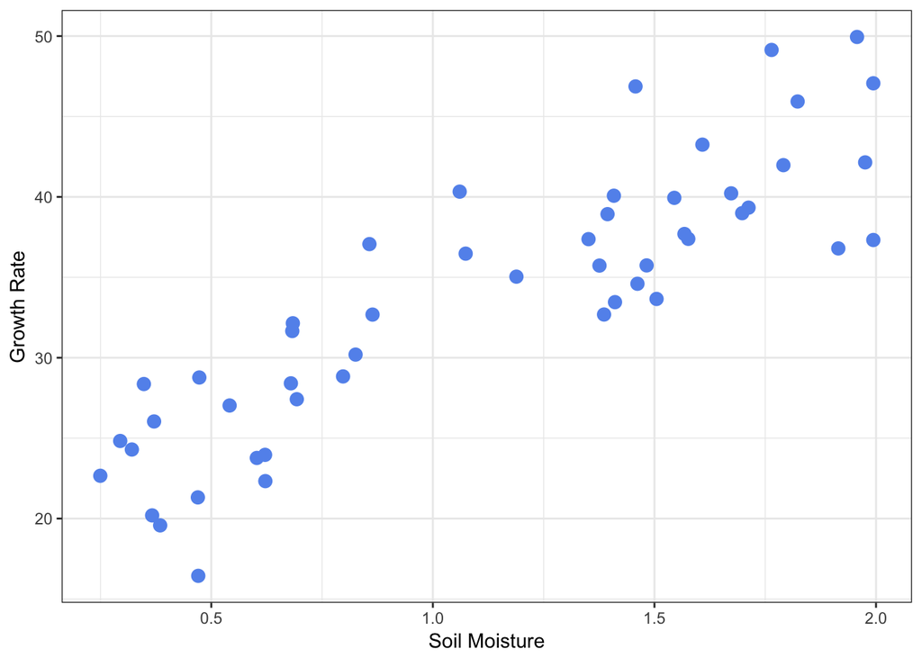

```r
ggplot(growth, aes(x = soil.moisture.content, y = plant.growth.rate)) +
  geom_point(col = "cornflowerblue", size = 3) +
  labs(x = "Soil Moisture", y = "Growth Rate") +
  theme_bw()
```

#### 2. Make a model

```r
model1 <- lm(plant.growth.rate ~ soil.moisture.content, data = growth)
```

#### 3. Check the assumptions using model diagnostics in `ggfortify`

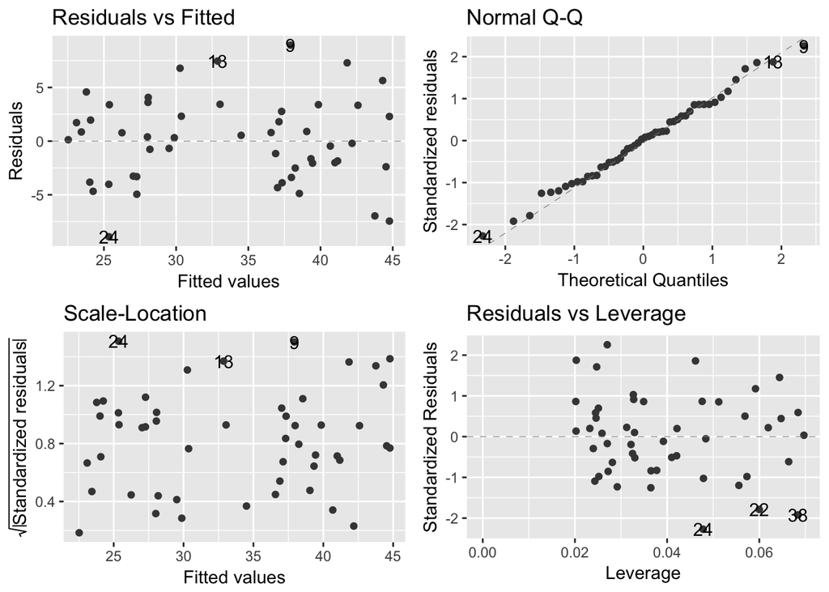

```r
autoplot(model1, smooth.colour = NA)
```

#### 4. Look at the results

We use `anova` to look at the **main effects**. Add notes so you know what the output means.

```r
anova(model1)
```

```
## Analysis of Variance Table
##
## Response: plant.growth.rate
##                       Df  Sum Sq Mean Sq F value    Pr(>F)
## soil.moisture.content  1 2521.15 2521.15  156.08 < 2.2e-16 ***
## Residuals             48  775.35   16.15
## ---
## Signif. codes:  0 '***' 0.001 '**' 0.01 '*' 0.05 '.' 0.1 ' ' 1
```

We use `summary` to look at the parameter estimates. Add notes so you know what the output means.

```r
summary(model1)
```

```
##
## Call:
## lm(formula = plant.growth.rate ~ soil.moisture.content, data = growth)
##
## Residuals:
##     Min      1Q  Median      3Q     Max
## -8.9089 -3.0747  0.2261  2.6567  8.9406
##
## Coefficients:
##                       Estimate Std. Error t value Pr(>|t|)
## (Intercept)             19.348      1.283   15.08   <2e-16 ***
## soil.moisture.content   12.750      1.021   12.49   <2e-16 ***
## ---
## Signif. codes:  0 '***' 0.001 '**' 0.01 '*' 0.05 '.' 0.1 ' ' 1
##
## Residual standard error: 4.019 on 48 degrees of freedom
## Multiple R-squared:  0.7648, Adjusted R-squared:  0.7599
## F-statistic: 156.1 on 1 and 48 DF,  p-value: < 2.2e-16
```

#### 5. Add interpretation to the graph

How do you add a regression line in `ggplot`?

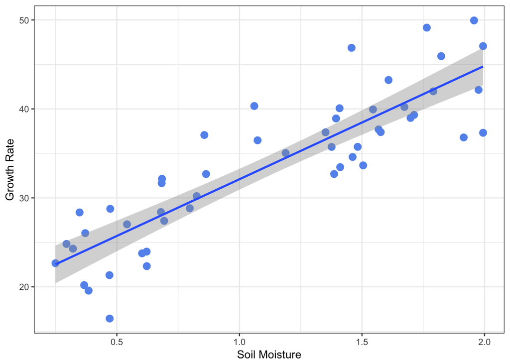

```r
ggplot(growth, aes(x = soil.moisture.content, y = plant.growth.rate)) +
    geom_point(col = "cornflowerblue", size = 3) +
  labs(x = "Soil Moisture", y = "Growth Rate") +
  theme_bw() +
  geom_smooth(method = "lm", se = TRUE)
```

`geom_smooth(method = “lm”)` is designed so you can explore your data quickly. However, it only draws the correct line and confidence intervals when you have one Y and one X variable. Otherwise we need a more complex workflow…

#### Adding lines to regression plots - predictions workflow

##### 1. Create a new X variable

It needs the same name as the one in your graph, ranging from the minimum and maximum values of the variable in your data. We can use `expand.grid` to do this, and the function `seq`.

```r
newX <- expand.grid(soil.moisture.content = seq(from = 0.25, to = 2, length = 100))

# Look at newX
head(newX)
```

```
##   soil.moisture.content
## 1             0.2500000
## 2             0.2676768
## 3             0.2853535
## 4             0.3030303
## 5             0.3207071
## 6             0.3383838
```

##### 2. Next make your new Y variable.

Use the model you created to predict what Y values go with the X values you just made. We can make predictions using `predict`. Look at `newY`. What are `fit`, `lwr` and `upr`?

```r
newY <- predict(model1, newdata = newX, interval = "confidence")

# Look at newY
head(newY)
```

```
##        fit      lwr      upr
## 1 22.53584 20.40348 24.66821
## 2 22.76121 20.65938 24.86304
## 3 22.98658 20.91510 25.05807
## 4 23.21196 21.17063 25.25328
## 5 23.43733 21.42595 25.44870
## 6 23.66270 21.68106 25.64433
```

##### 3. Stick `newX` and `newY` together into one dataframe.

```r
addThese <- data.frame(newX, newY)

# Look at addThese
head(addThese)
```

```
##   soil.moisture.content      fit      lwr      upr
## 1             0.2500000 22.53584 20.40348 24.66821
## 2             0.2676768 22.76121 20.65938 24.86304
## 3             0.2853535 22.98658 20.91510 25.05807
## 4             0.3030303 23.21196 21.17063 25.25328
## 5             0.3207071 23.43733 21.42595 25.44870
## 6             0.3383838 23.66270 21.68106 25.64433
```

##### 4. Rename `fit` to the name of your Y variable

In this case `plant.growth.rate`.

```r
addThese <- rename(addThese, plant.growth.rate = fit)

# Look at addThese
head(addThese)
```

```
##   soil.moisture.content plant.growth.rate      lwr      upr
## 1             0.2500000          22.53584 20.40348 24.66821
## 2             0.2676768          22.76121 20.65938 24.86304
## 3             0.2853535          22.98658 20.91510 25.05807
## 4             0.3030303          23.21196 21.17063 25.25328
## 5             0.3207071          23.43733 21.42595 25.44870
## 6             0.3383838          23.66270 21.68106 25.64433
```

##### 5. Plot the graph!

We plot the same graph as earlier, but with a different `geom_smooth` line. Note that we are using the `addThese` data for the line, and the `growth` data for the original data points.

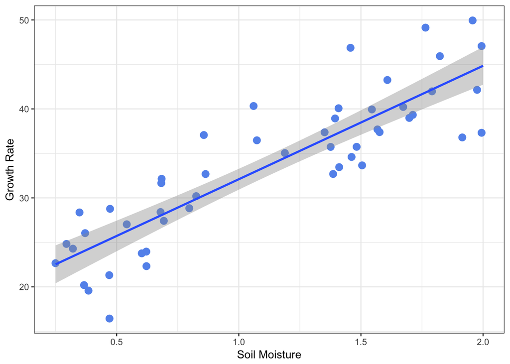

```r
ggplot(growth, aes(x = soil.moisture.content, y = plant.growth.rate)) +
  geom_point(col = "cornflowerblue", size = 3) +
  labs(x = "Soil Moisture", y = "Growth Rate") +
  theme_bw() +
  geom_smooth(data = addThese, aes(ymin = lwr, ymax = upr), stat = "identity")
```

Note there is a bug in `ggplot2` which means you might get the error message `Ignoring unknown aesthetics: ymin, ymax`. Just ignore this!

##### Getting specific predictions

If you want to predict the value of `soil.moisture.content = 1.25`:

```r
newX <- expand.grid(soil.moisture.content = 1.25)
prediction <- predict(model1, newdata = newX, interval = "confidence")

# Look at the prediction
prediction
```

```
##        fit      lwr      upr
## 1 35.28538 34.11519 36.45557
```

### General linear models - ANOVA

Next we will move on to ANOVA - analysis of variance.

To start, we need to add the data and look at it. We are going to work with the dataset `daphnia.growth.csv`.

```r
daphnia <- read_csv("daphnia.growth.csv")
glimpse(daphnia)
```

```
## Observations: 40
## Variables: 3
## $ parasite    <chr> "control", "control", "control", "control", "contr...
## $ rep         <int> 1, 2, 3, 4, 5, 6, 7, 8, 9, 10, 1, 2, 3, 4, 5, 6, 7...
## $ growth.rate <dbl> 1.0747092, 1.2659016, 1.3151563, 1.0757519, 1.1967...
```

We will then follow the same steps as before:

1. PLOT your data
2. Fit your model
3. Look at the assumptions
4. Look at the results
5. Add interpretation to your graph

#### 1. Plot the data

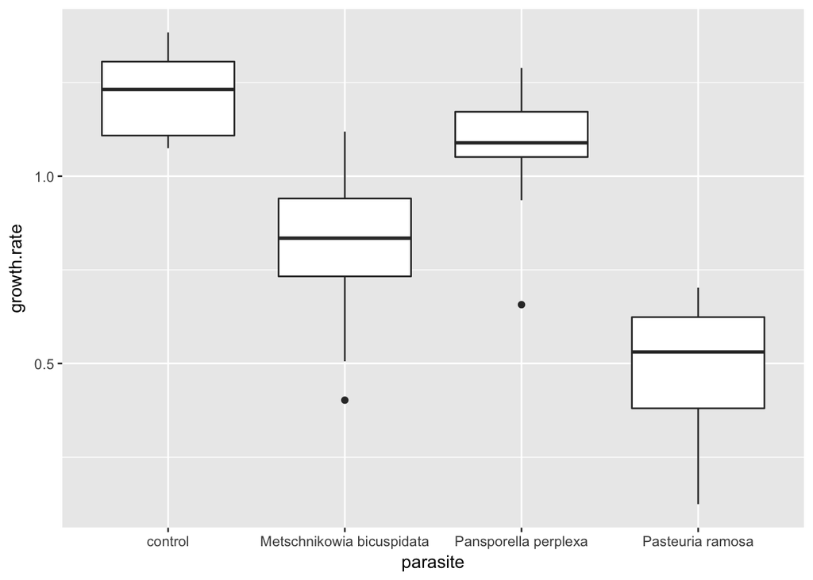

```r
ggplot(daphnia, aes(x = parasite, y = growth.rate)) +
  geom_boxplot()
```

To draw the other plot in the presentation…

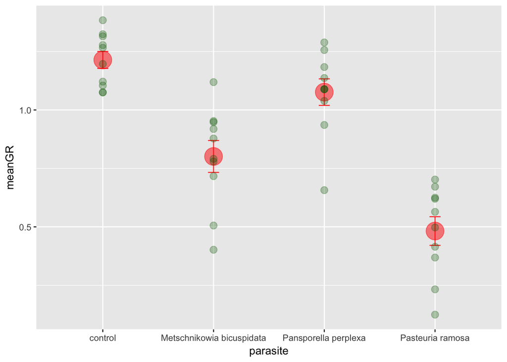

```r
# summarise the data by parasite
growth.stats <-
daphnia %>%
    group_by(parasite) %>%
        summarise(
            meanGR = mean(growth.rate),
            seGR = sd(growth.rate)/sqrt(n()),
            lwr = meanGR - seGR,
            upr = meanGR + seGR)

# plot the graph
# note that we use the growth stats first,
# then add the raw data....

ggplot(growth.stats, aes(x = parasite, y = meanGR)) +
    #first add the points from the growth stats"
    geom_point(colour = "red", size = 8, alpha = 0.5) +

    # now add the error bars
    geom_errorbar(aes(ymin = lwr, ymax = upr), width = 0.1, col = "red", alpha = 0.8) +

    # now add the raw data from the original dataframe
    geom_point(data = daphnia, aes(x = parasite, y = growth.rate), size = 3,
        colour = "darkgreen", alpha = 0.3)
```

#### 2. Make a model

```r
model2 <- lm(growth.rate ~ parasite, data = daphnia)
```

#### 3. Check the assumptions using model diagnostics in `ggfortify`

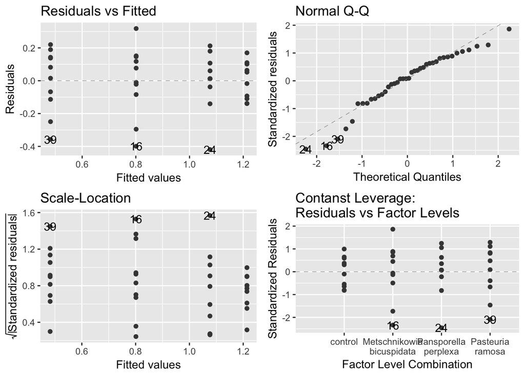

```r
autoplot(model2, smooth.colour = NA)
```

#### 4. Look at the results

We use `anova` to look at the **main effects**. Add notes so you know what the output means.

```r
anova(model2)
```

```
## Analysis of Variance Table
##
## Response: growth.rate
##           Df Sum Sq Mean Sq F value    Pr(>F)
## parasite   3 3.1379 1.04597  32.325 2.571e-10 ***
## Residuals 36 1.1649 0.03236
## ---
## Signif. codes:  0 '***' 0.001 '**' 0.01 '*' 0.05 '.' 0.1 ' ' 1
```

We use `summary` to look at the parameter estimates. Add notes so you know what the output means.

```r
summary(model2)
```

```
##
## Call:
## lm(formula = growth.rate ~ parasite, data = daphnia)
##
## Residuals:
##      Min       1Q   Median       3Q      Max
## -0.41930 -0.09696  0.01408  0.12267  0.31790
##
## Coefficients:
##                                   Estimate Std. Error t value Pr(>|t|)
## (Intercept)                        1.21391    0.05688  21.340  < 2e-16 ***
## parasiteMetschnikowia bicuspidata -0.41275    0.08045  -5.131 1.01e-05 ***
## parasitePansporella perplexa      -0.13755    0.08045  -1.710   0.0959 .
## parasitePasteuria ramosa          -0.73171    0.08045  -9.096 7.34e-11 ***
## ---
## Signif. codes:  0 '***' 0.001 '**' 0.01 '*' 0.05 '.' 0.1 ' ' 1
##
## Residual standard error: 0.1799 on 36 degrees of freedom
## Multiple R-squared:  0.7293, Adjusted R-squared:  0.7067
## F-statistic: 32.33 on 3 and 36 DF,  p-value: 2.571e-10
```

#### Releveling when reference is not alphabetically first

This is pretty simple, you just set as the `ref` whatever all your groups need to be compared to. Note that you need to tell R to treat `parasite` as a factor using `as.factor`.

```r
daphnia.relevel <- mutate(daphnia, parasite = relevel(as.factor(parasite), ref = "Pasteuria ramosa"))
```

So you can see that it worked, plot the boxplot again

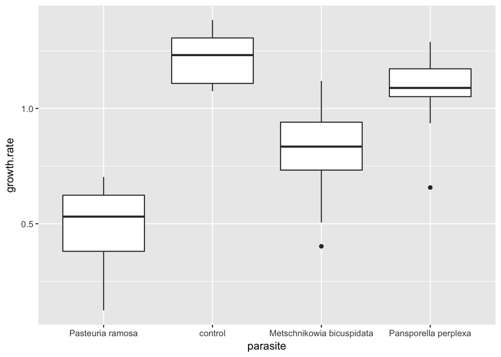

```r
ggplot(daphnia.relevel, aes(x = parasite, y = growth.rate)) +
  geom_boxplot()
```

#### How to fit a Tukey test or another *post-hoc* comparison

If you have a balanced design this is easy. First change the model as it is fitted using `aov` not `lm`, then use `TukeyHSD`.

```r
model2.aov <- aov(model2) # repackage the model for a Tukey Test
tukey.out <- TukeyHSD(model2.aov) # generate Tukey test
tukey.out
```

```
##   Tukey multiple comparisons of means
##     95% family-wise confidence level
##
## Fit: aov(formula = model2)
##
## $parasite
##                                                      diff         lwr
## Metschnikowia bicuspidata-control              -0.4127547 -0.62941363
## Pansporella perplexa-control                   -0.1375537 -0.35421267
## Pasteuria ramosa-control                       -0.7317058 -0.94836477
## Pansporella perplexa-Metschnikowia bicuspidata  0.2752010  0.05854199
## Pasteuria ramosa-Metschnikowia bicuspidata     -0.3189511 -0.53561011
## Pasteuria ramosa-Pansporella perplexa          -0.5941521 -0.81081106
##                                                        upr     p adj
## Metschnikowia bicuspidata-control              -0.19609571 0.0000576
## Pansporella perplexa-control                    0.07910525 0.3335411
## Pasteuria ramosa-control                       -0.51504685 0.0000000
## Pansporella perplexa-Metschnikowia bicuspidata  0.49185992 0.0081622
## Pasteuria ramosa-Metschnikowia bicuspidata     -0.10229218 0.0018196
## Pasteuria ramosa-Pansporella perplexa          -0.37749314 0.0000001
```

Alternatively you can use the package `multicomp`. Remember to install it first. *CAVEAT, loading `multicomp` will mask the `dplyr` function `select`*. To fix you have to shut down R and start it up again. I have commented this out here to prevent this issue.

```r
# library(multcomp)
# Requires parasite to be a factor, so we need to mutate it in the data first
# daphnia <- mutate(daphnia, parasite = as.factor(parasite))
# Run the model
# model2 <- lm(growth.rate ~ parasite, data = daphnia)
# Use the Tukey test
# tukey.par <- glht(model2, linfct = mcp(parasite = "Tukey"))
# summary(tukey.par)
```

### General linear models - ANCOVA

Next we will move on to ANCOVA - analysis of covariance.

To start, we need to add the data and look at it. We are going to work with the dataset `limpet.csv`.

```r
limpet <- read_csv("limpet.csv")
glimpse(limpet)
```

```
## Observations: 24
## Variables: 3
## $ DENSITY <int> 8, 8, 8, 8, 8, 8, 15, 15, 15, 15, 15, 15, 30, 30, 30, ...
## $ SEASON  <chr> "spring", "spring", "spring", "summer", "summer", "sum...
## $ EGGS    <dbl> 2.875, 2.625, 1.750, 2.125, 1.500, 1.875, 2.600, 1.866...
```

We will then follow the same steps as before:

1. PLOT your data
2. Fit your model
3. Look at the assumptions
4. Look at the results
5. Add interpretation to your graph

#### 1. Plot the data

Make a scatter plot of `DENSITY` on the x axis and `EGGS` on the y axis, coloured by `SEASON`.

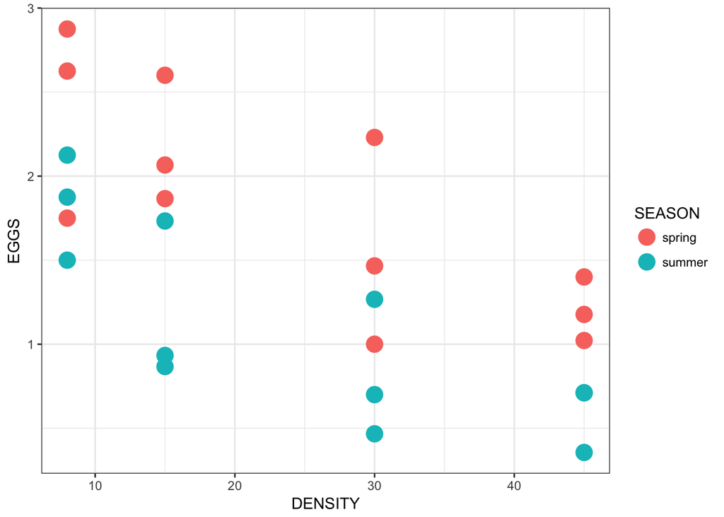

```r
ggplot(limpet, aes(x = DENSITY, y = EGGS, colour = SEASON)) +
    geom_point(size = 5) +
  theme_bw()
```

#### 2. Make a model (with an interaction term)

```r
model3 <- lm(EGGS ~ DENSITY * SEASON, data = limpet)
# Note that the * is shorthand for:
# model3 <- lm(EGGS ~ DENSITY + SEASON + SEASON:DENSITY, data = limpet)
```

#### 3. Check the assumptions using model diagnostics in `ggfortify`

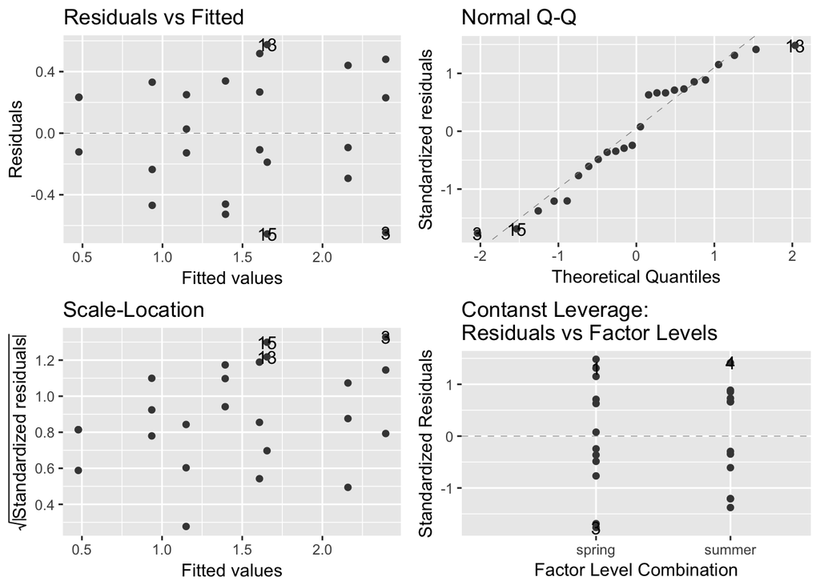

```r
autoplot(model3, smooth.colour = NA)
```

#### 4. Look at the results

We use `anova` to look at the **main effects**. Add notes so you know what the output means.

```r
anova(model3)
```

```
## Analysis of Variance Table
##
## Response: EGGS
##                Df Sum Sq Mean Sq F value    Pr(>F)
## DENSITY         1 5.0241  5.0241 30.1971 2.226e-05 ***
## SEASON          1 3.2502  3.2502 19.5350 0.0002637 ***
## DENSITY:SEASON  1 0.0118  0.0118  0.0711 0.7925333
## Residuals      20 3.3275  0.1664
## ---
## Signif. codes:  0 '***' 0.001 '**' 0.01 '*' 0.05 '.' 0.1 ' ' 1
```

We use `summary` to look at the parameter estimates. Add notes so you know what the output means.

```r
summary(model3)
```

```
##
## Call:
## lm(formula = EGGS ~ DENSITY * SEASON, data = limpet)
##
## Residuals:
##      Min       1Q   Median       3Q      Max
## -0.65468 -0.25021 -0.03318  0.28335  0.57532
##
## Coefficients:
##                       Estimate Std. Error t value Pr(>|t|)
## (Intercept)           2.664166   0.234118  11.380 3.45e-10 ***
## DENSITY              -0.033650   0.008259  -4.074 0.000591 ***
## SEASONsummer         -0.812282   0.331092  -2.453 0.023450 *
## DENSITY:SEASONsummer  0.003114   0.011680   0.267 0.792533
## ---
## Signif. codes:  0 '***' 0.001 '**' 0.01 '*' 0.05 '.' 0.1 ' ' 1
##
## Residual standard error: 0.4079 on 20 degrees of freedom
## Multiple R-squared:  0.7135, Adjusted R-squared:  0.6705
## F-statistic:  16.6 on 3 and 20 DF,  p-value: 1.186e-05
```

#### 5. Add interpretation to the graph

How do you add a regression line in `ggplot`?

#### Adding lines to regression plots - predictions workflow

##### 1. Create a new X variable.

It needs the same name as the one in your graph, ranging from the minimum and maximum values of the variable in your data. We can use `expand.grid` to do this, and the function `seq`.

```r
newX <- expand.grid(DENSITY = seq(from = 8, to = 45, length = 100),
                    SEASON = c("spring", "summer"))

# Look at newX
head(newX)
```

```
##    DENSITY SEASON
## 1 8.000000 spring
## 2 8.373737 spring
## 3 8.747475 spring
## 4 9.121212 spring
## 5 9.494949 spring
## 6 9.868687 spring
```

##### 2. Next make your new Y variable.

Use the model you created to predict what Y values go with the X values you just made. We can make predictions using `predict`. Look at `newY`. What are `fit`, `lwr` and `upr`?

```r
newY <- predict(model3, newdata = newX, interval = "confidence")

# Look at newY
head(newY)
```

```
##        fit      lwr      upr
## 1 2.394969 2.019285 2.770654
## 2 2.382393 2.011557 2.753229
## 3 2.369817 2.003780 2.735854
## 4 2.357241 1.995952 2.718529
## 5 2.344665 1.988071 2.701258
## 6 2.332089 1.980135 2.684042
```

##### 3. Stick `newX` and `newY` together into one dataframe.

```r
addThese <- data.frame(newX, newY)

# Look at addThese
head(addThese)
```

```
##    DENSITY SEASON      fit      lwr      upr
## 1 8.000000 spring 2.394969 2.019285 2.770654
## 2 8.373737 spring 2.382393 2.011557 2.753229
## 3 8.747475 spring 2.369817 2.003780 2.735854
## 4 9.121212 spring 2.357241 1.995952 2.718529
## 5 9.494949 spring 2.344665 1.988071 2.701258
## 6 9.868687 spring 2.332089 1.980135 2.684042
```

##### 4. Rename `fit` to the name of your Y variable.

In this case `EGGS`.

```r
addThese <- rename(addThese, EGGS = fit)

# Look at addThese
head(addThese)
```

```
##    DENSITY SEASON     EGGS      lwr      upr
## 1 8.000000 spring 2.394969 2.019285 2.770654
## 2 8.373737 spring 2.382393 2.011557 2.753229
## 3 8.747475 spring 2.369817 2.003780 2.735854
## 4 9.121212 spring 2.357241 1.995952 2.718529
## 5 9.494949 spring 2.344665 1.988071 2.701258
## 6 9.868687 spring 2.332089 1.980135 2.684042
```

##### 5. Plot the graph!

We plot the same graph as earlier, but with a different `geom_smooth` line. Note that we are using the `addThese` data for the line, and the `limpet` data for the original data points.

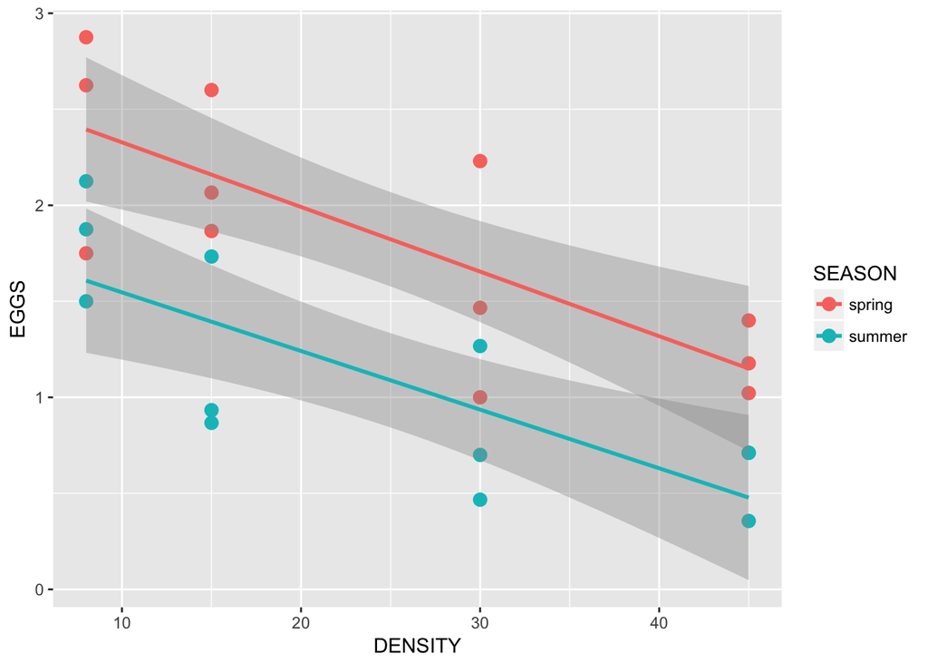

```r
ggplot(limpet, aes(x = DENSITY, y = EGGS, colour = SEASON)) +
  geom_point(size = 3) +
  geom_smooth(data = addThese, aes(ymin = lwr, ymax = upr), stat = "identity")
```

Note there is a bug in `ggplot2` which means you might get the error message `Ignoring unknown aesthetics: ymin, ymax`. Just ignore this!

If you want to set custom colours you can do so for the raw data (colour) and the bands (fill).

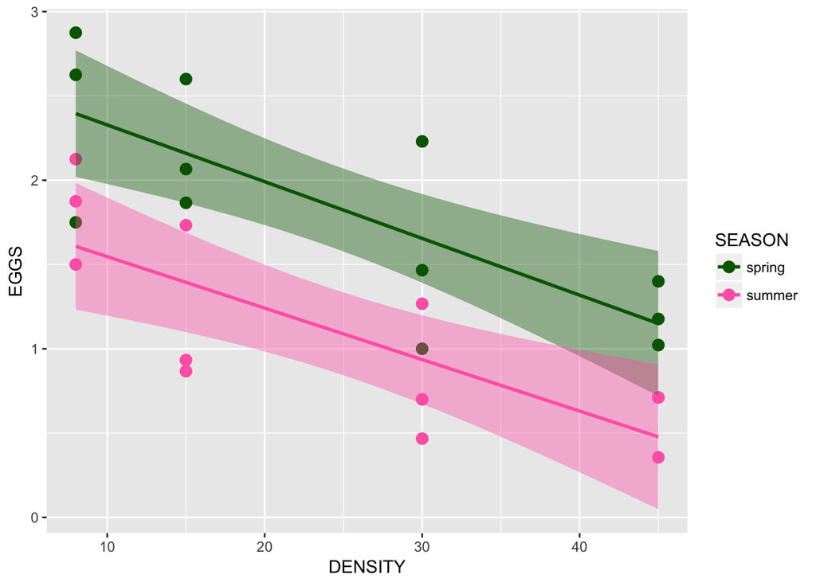

```r
ggplot(limpet, aes(x = DENSITY, y = EGGS, colour = SEASON, fill = SEASON)) +
  geom_point(size = 3) +
  geom_smooth(data = addThese, aes(ymin = lwr, ymax = upr), stat = "identity") +
  scale_colour_manual(values = c("darkgreen", "hotpink")) +
  scale_fill_manual(values = c("darkgreen", "hotpink"))
```

##### Getting specific predictions

If you want to predict the value of `EGGS` for `DENSITY = 40` and `SEASON = spring`:

```r
newX <- expand.grid(DENSITY = 40, SEASON = "spring")
prediction <- predict(model3, newdata = newX, interval = "confidence")

# Look at the prediction
prediction
```

```
##       fit       lwr      upr
## 1 1.31818 0.9553575 1.681003
```

### T-tests

Let’s do some slightly simpler tests now and look at the t-test.

To start, we need to add the data and look at it. We are going to work with the dataset `garden.ozone.csv`.

```r
ozone <- read_csv("garden.ozone.csv")
glimpse(ozone)
```

```
## Observations: 20
## Variables: 3
## $ Ozone           <dbl> 61.7, 64.0, 72.4, 56.8, 52.4, 44.8, 70.4, 67.6...
## $ Garden.location <chr> "West", "West", "West", "West", "West", "West"...
## $ Garden.ID       <chr> "G1", "G2", "G3", "G4", "G5", "G6", "G7", "G8"...
```

We will then follow the same steps as before:

1. PLOT your data
2. Fit your model
3. Look at the assumptions
4. Look at the results
5. Add interpretation to your graph

#### 1. Plot the data

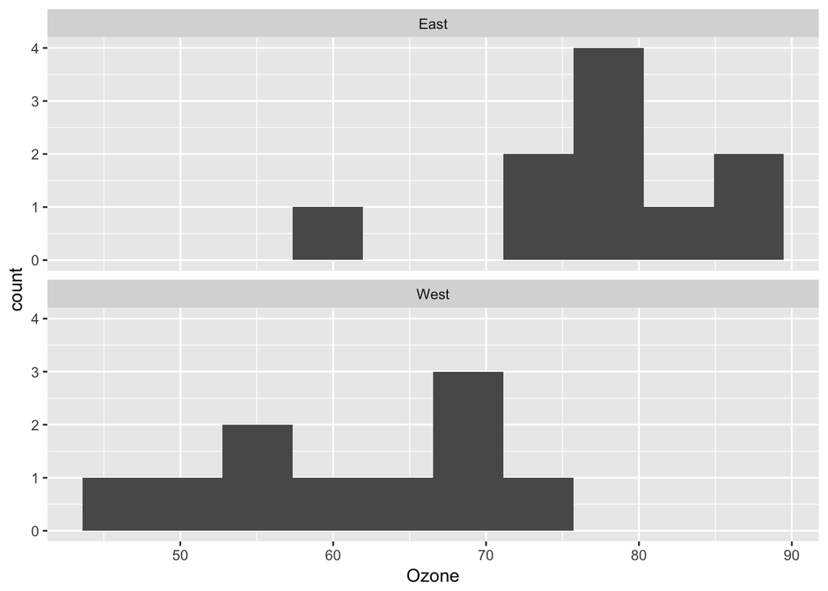

```r
ggplot(ozone, aes(x = Ozone)) +
  geom_histogram(bins = 10) +
  facet_wrap(~Garden.location, ncol = 1)
```

#### 2. Make a model

```r
model4 <- t.test(Ozone ~ Garden.location,
       data = ozone,
       var.equal = FALSE)
```

#### 3. Check the assumptions

What are the assumptions of a t-test?

```r
ozone %>%
  group_by(Garden.location) %>%
  summarise(meanOzone = mean(Ozone),
              varOzone = var(Ozone))
```

```
## # A tibble: 2 x 3
##   Garden.location meanOzone varOzone
##   <chr>               <dbl>    <dbl>
## 1 East                 77.3     62.0
## 2 West                 61.3     82.1
```

#### 4. Look at the results

```r
model4
```

```
##
##  Welch Two Sample t-test
##
## data:  Ozone by Garden.location
## t = 4.2363, df = 17.656, p-value = 0.0005159
## alternative hypothesis: true difference in means is not equal to 0
## 95 percent confidence interval:
##   8.094171 24.065829
## sample estimates:
## mean in group East mean in group West
##              77.34              61.26
```

Note that this is a Welch’s t-test, because we don’t have equal variances. R will fit this kind of t-test by default.

Another way to plot the results with all the data.

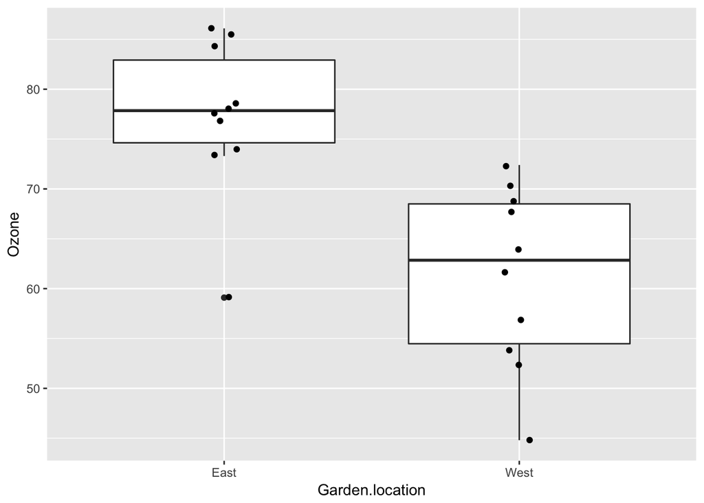

```r
ggplot(ozone, aes(x = Garden.location, y = Ozone)) +
  geom_boxplot() +
  geom_point(position = position_jitter(width = 0.05))
```

### Chi Squared tests

Finally let’s do a chi squared test.

To start, we need to add the data and look at it. We are going to work with the dataset `ladybirds.csv`.

```r
ladybird <- read_csv("ladybirds.csv")
glimpse(ladybird)
```

```
## Observations: 20
## Variables: 4
## $ Habitat <chr> "Rural", "Rural", "Rural", "Rural", "Rural", "Rural", ...
## $ Site    <chr> "R1", "R2", "R3", "R4", "R5", "R1", "R2", "R3", "R4", ...
## $ colour  <chr> "black", "black", "black", "black", "black", "red", "r...
## $ number  <int> 10, 3, 4, 7, 6, 15, 18, 9, 12, 16, 32, 25, 25, 17, 16,...
```

We will then follow the same steps as before:

1. PLOT your data
2. Fit your model
3. Look at the assumptions
4. Look at the results
5. Add interpretation to your graph

#### 1. Plot the data

This is a little tricker for Chi squared, as the numbers we are interested in are the total number of ladybirds in each of four groups - black rural, black urban, red rural and red urban. So first we need to extract these numbers using `dplyr`.

```r
lb <-
  ladybird %>%
  group_by(Habitat, colour) %>%
  summarise(obs = sum(number))

# Look at lb
lb
```

```
## # A tibble: 4 x 3
## # Groups:   Habitat [?]
##   Habitat    colour   obs
##   <chr>      <chr>  <int>
## 1 Industrial black    115
## 2 Industrial red       85
## 3 Rural      black     30
## 4 Rural      red       70
```

We can then plot a barplot (yuk)

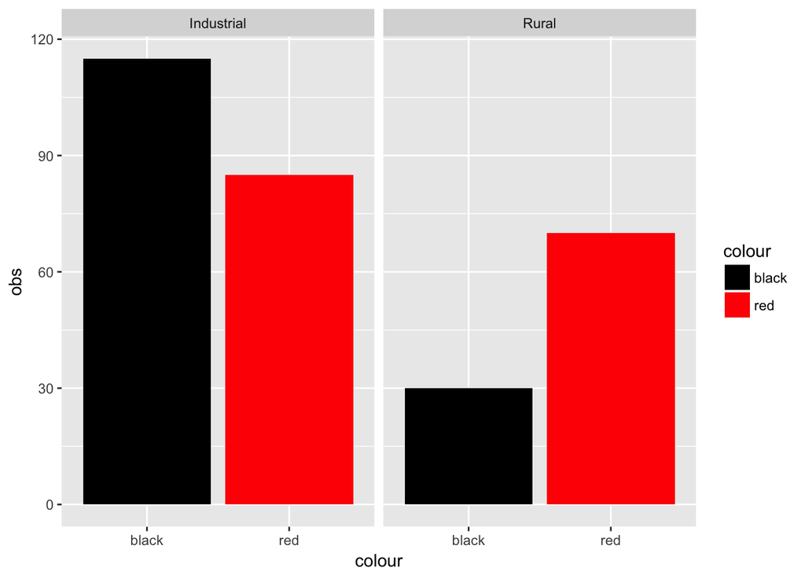

```r
ggplot(lb, aes(x = colour, y = obs, fill = colour)) +
  geom_bar(stat = "identity") +
    facet_wrap(~Habitat) +
  scale_fill_manual(values = c(black = "black", red = "red"))
```

#### 2. Make a model

This bit is also slightly different as we need the numbers to be in a matrix. In a chi square test we call this matrix a *contingency table*. We can make one using a function called `xtabs`.

```r
lb.matrix <- xtabs(obs ~ Habitat + colour, data = lb)

# Look at it
lb.matrix
```

```
##             colour
## Habitat      black red
##   Industrial   115  85
##   Rural         30  70
```

We can then perform the test.

```r
chisq.test(lb.matrix)
```

```
##
##  Pearson's Chi-squared test with Yates' continuity correction
##
## data:  lb.matrix
## X-squared = 19.103, df = 1, p-value = 1.239e-05
```

### General linear models - two way ANOVA

We are not going to talk about this at all, but for completeness here is a two way ANOVA example.

To start, we need to add the data and look at it. We are going to work with the dataset `growth.csv`.

```r
cows <- read_csv("growth.csv")
glimpse(cows)
```

```
## Observations: 48
## Variables: 3
## $ supplement <chr> "supergain", "supergain", "supergain", "supergain",...
## $ diet       <chr> "wheat", "wheat", "wheat", "wheat", "wheat", "wheat...
## $ gain       <dbl> 17.37125, 16.81489, 18.08184, 15.78175, 17.70656, 1...
```

We will then follow the same steps as before:

1. PLOT your data
2. Fit your model
3. Look at the assumptions
4. Look at the results
5. Add interpretation to your graph

#### 1. Plot the data

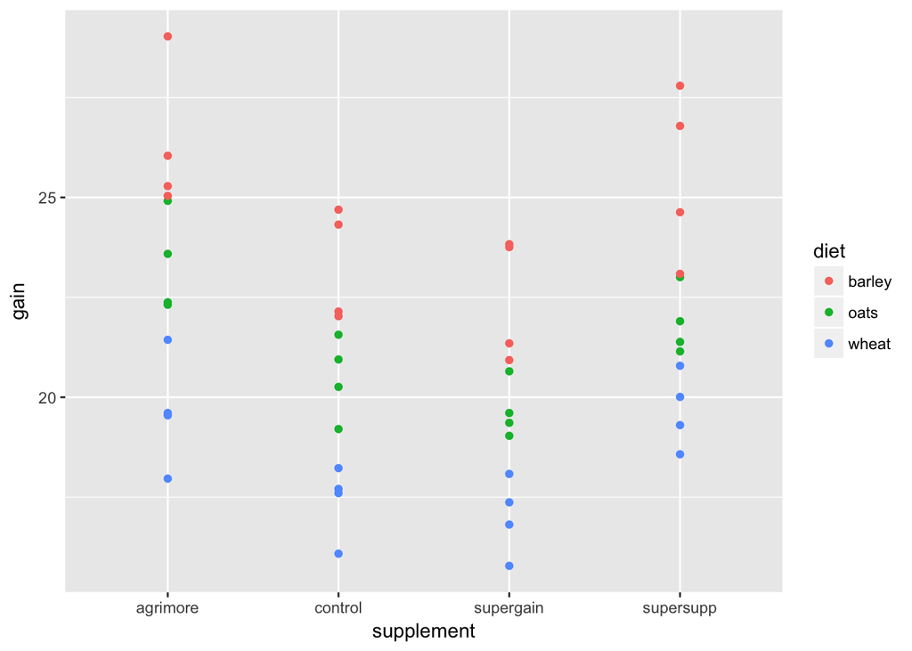

```r
ggplot(cows, aes(x = supplement, y = gain, colour = diet)) +
    geom_point()
```

You have probably noticed that we have a problem here - the first thing alphabetically is **not** the control. So we need to relevel.

```r
cows <- mutate(cows, supplement = relevel(as.factor(supplement), ref = "control"))
```

Plot it again to check it worked.

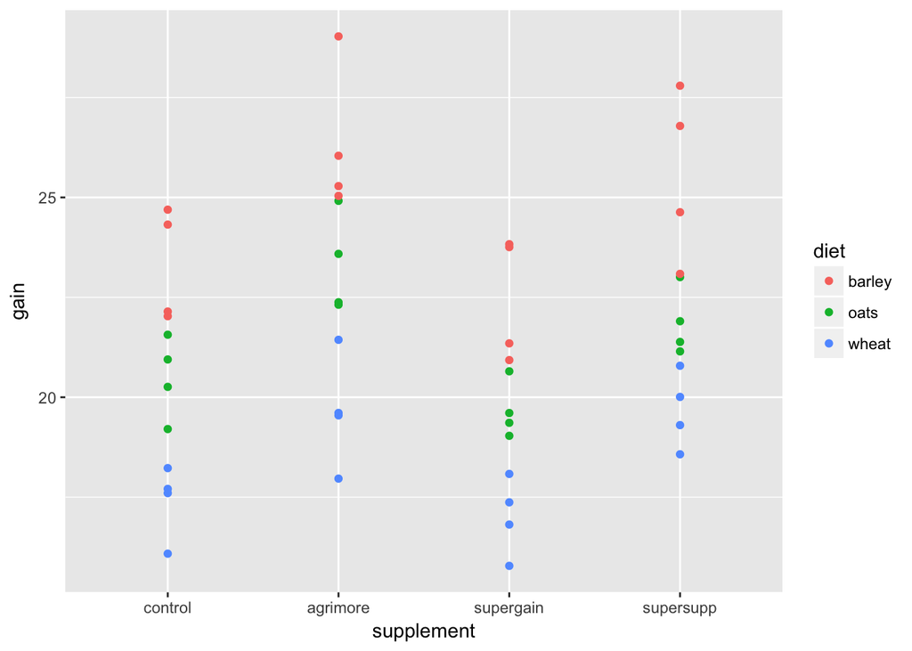

```r
ggplot(cows, aes(x = supplement, y = gain, colour = diet)) +
    geom_point()
```

#### 2. Make a model (with an interaction term)

```r
model5 <- lm(gain ~ supplement*diet, data = cows)
```

#### 3. Check the assumptions using model diagnostics in `ggfortify`

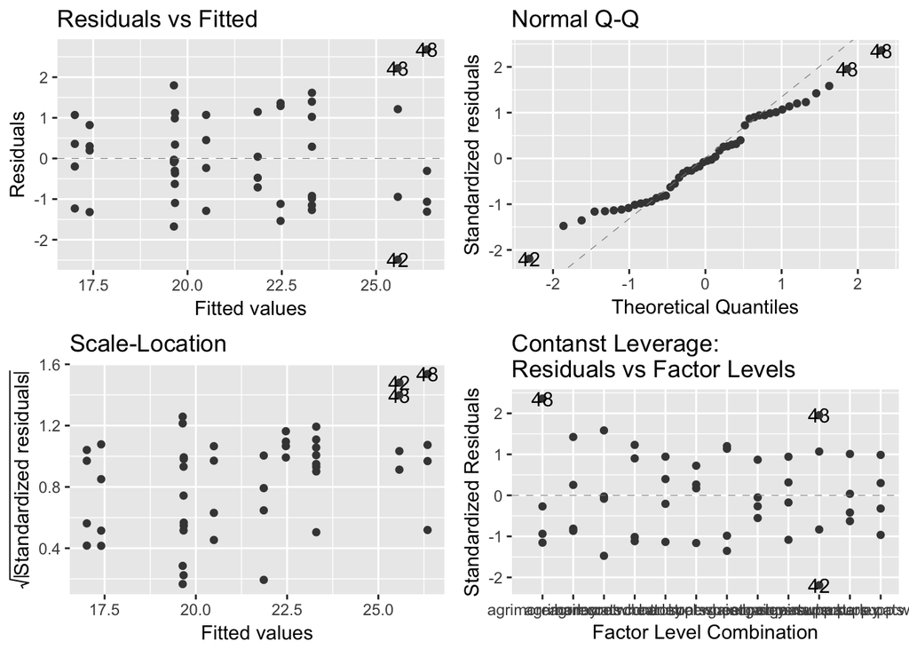

```r
autoplot(model5, smooth.colour = NA)
```

#### 4. Look at the results

We use `anova` to look at the **main effects**. Add notes so you know what the output means. There is little evidence of an interaction, but strong main effects.

```r
anova(model5)
```

```
## Analysis of Variance Table
##
## Response: gain
##                 Df  Sum Sq Mean Sq F value    Pr(>F)
## supplement       3  91.881  30.627 17.8150 2.952e-07 ***
## diet             2 287.171 143.586 83.5201 2.999e-14 ***
## supplement:diet  6   3.406   0.568  0.3302    0.9166
## Residuals       36  61.890   1.719
## ---
## Signif. codes:  0 '***' 0.001 '**' 0.01 '*' 0.05 '.' 0.1 ' ' 1
```

We use `summary` to look at the parameter estimates. Add notes so you know what the output means. The table looks rather scary, but is explained in the powerpoint presentation. It is similar to the ANCOVA/ANOVA outputs.

```r
summary(model5)
```

```
##
## Call:
## lm(formula = gain ~ supplement * diet, data = cows)
##
## Residuals:
##      Min       1Q   Median       3Q      Max
## -2.48756 -1.00368 -0.07452  1.03496  2.68069
##
## Coefficients:
##                                 Estimate Std. Error t value Pr(>|t|)
## (Intercept)                   23.2966499  0.6555863  35.536  < 2e-16 ***
## supplementagrimore             3.0518277  0.9271390   3.292  0.00224 **
## supplementsupergain           -0.8305263  0.9271390  -0.896  0.37631
## supplementsupersupp            2.2786527  0.9271390   2.458  0.01893 *
## dietoats                      -2.8029851  0.9271390  -3.023  0.00459 **
## dietwheat                     -5.8911317  0.9271390  -6.354 2.34e-07 ***
## supplementagrimore:dietoats   -0.2471088  1.3111726  -0.188  0.85157
## supplementsupergain:dietoats  -0.0001351  1.3111726   0.000  0.99992
## supplementsupersupp:dietoats  -0.9120830  1.3111726  -0.696  0.49113
## supplementagrimore:dietwheat  -0.8182729  1.3111726  -0.624  0.53651
## supplementsupergain:dietwheat  0.4374395  1.3111726   0.334  0.74060
## supplementsupersupp:dietwheat -0.0158299  1.3111726  -0.012  0.99043
## ---
## Signif. codes:  0 '***' 0.001 '**' 0.01 '*' 0.05 '.' 0.1 ' ' 1
##
## Residual standard error: 1.311 on 36 degrees of freedom
## Multiple R-squared:  0.8607, Adjusted R-squared:  0.8182
## F-statistic: 20.22 on 11 and 36 DF,  p-value: 3.295e-12
```